# Linear Models & Least Squares

INFO 521 · Module 1 · Lecture B — Normal Equations & Geometry

Greg Chism

College of Information Science · University of Arizona

August 2026

## Learning outcomes

By the end of Lecture B you should be able to:

1. **Derive the closed form** — scalar first, then the matrix normal equations for $\hat{\mathbf{w}}$.
2. **Interpret least squares as an orthogonal projection** onto $\mathrm{col}(\mathbf{X})$, and identify the **hat matrix** $\mathbf{P}$.
3. **Extend to basis functions** — fit curves while staying linear in the weights.
4. **State the uniqueness condition** for $\hat{\mathbf{w}}$.

## Recap (Lecture A)

We have a **model** and a **loss**:

$$\hat{y} = \mathbf{w}^{\!\top}\mathbf{x},
\qquad
\mathcal{L}(\mathbf{w}) = \tfrac{1}{N}\,\lVert \mathbf{y} - \mathbf{X}\mathbf{w}\rVert_2^2 .$$

Now: which $\mathbf{w}$ makes $\mathcal{L}$ smallest?

# Solve it: set the gradient to zero.

## The loss surface

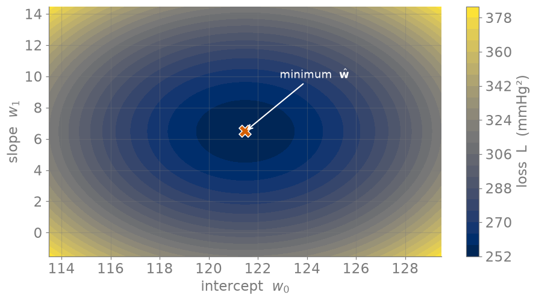

Figure 1: Loss surface L(w₀, w₁) for SBP on standardized age — a single convex basin.

## Scalar least squares: the closed form

Start in 1-D — model $\hat{y}_n = w_0 + w_1 x_n$ — and set both partials of $\mathcal{L}=\tfrac{1}{N}\sum_n (y_n - w_0 - w_1 x_n)^2$ to zero.

$$\frac{\partial \mathcal{L}}{\partial w_0} = 0
\qquad\Longrightarrow\qquad
\hat{w}_0 = \bar{y} - \hat{w}_1 \bar{x}$$

$$\frac{\partial \mathcal{L}}{\partial w_1} = 0
\qquad\Longrightarrow\qquad
\hat{w}_1 = \frac{\sum_n (x_n - \bar{x})(y_n - \bar{y})}{\sum_n (x_n - \bar{x})^2}$$

That is $\hat{w}_1 = \dfrac{\widehat{\mathrm{cov}}(x,y)}{\widehat{\mathrm{var}}(x)}$ — exactly the line you fit in Lecture A.

## The gradient

Now **scale to all $D$ features at once** — the scalar result becomes one matrix equation. $\mathcal{L}$ is quadratic in $\mathbf{w}$; differentiate the matrix form:

$$\mathcal{L}(\mathbf{w}) = \tfrac{1}{N}(\mathbf{y} - \mathbf{X}\mathbf{w})^{\!\top}(\mathbf{y} - \mathbf{X}\mathbf{w})$$

$$\nabla_{\mathbf{w}}\mathcal{L} = -\tfrac{2}{N}\,\mathbf{X}^{\!\top}(\mathbf{y} - \mathbf{X}\mathbf{w})$$

## The normal equations

Set the gradient to zero. The $-2/N$ drops out, leaving:

$$\mathbf{X}^{\!\top}(\mathbf{y} - \mathbf{X}\hat{\mathbf{w}}) = \mathbf{0}
\qquad\Longrightarrow\qquad
\mathbf{X}^{\!\top}\mathbf{X}\,\hat{\mathbf{w}} = \mathbf{X}^{\!\top}\mathbf{y} .$$

These are the **normal equations** — a $D{\times}D$ linear system for $\hat{\mathbf{w}}$.

## The solution

When $\mathbf{X}^{\!\top}\mathbf{X}$ is invertible, solve the system:

$$\boxed{\;\hat{\mathbf{w}} = \left(\mathbf{X}^{\!\top}\mathbf{X}\right)^{-1}\mathbf{X}^{\!\top}\mathbf{y}\;}$$

In practice we **solve the linear system** rather than form the inverse — `np.linalg.solve(X.T @ X, X.T @ y)` — better conditioned, less work.

The scalar formulas (intercept + slope) are exactly the $D=1$ case of this. Full vector-calculus derivation → appendix-matrix-calculus.html.

## Closed-form fit on NHANES

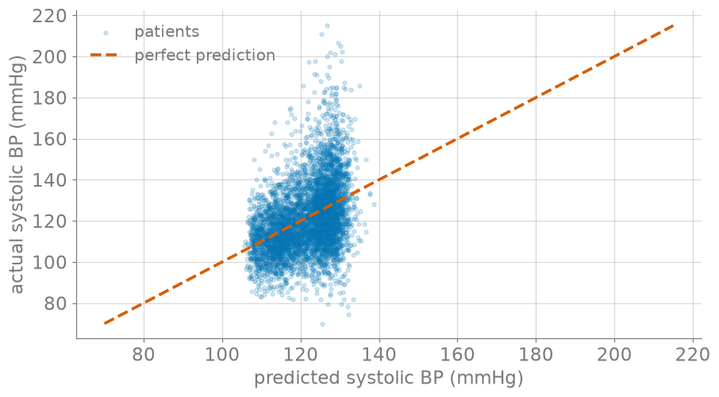

Figure 2: Six-feature closed-form fit: predicted vs. actual systolic BP (dashed = perfect prediction).

# What least squares is doing: geometry.

## Least squares is a projection

Think in $\mathbb{R}^{N}$ (one axis per patient): $\mathbf{y}$ is a point, and every $\mathbf{X}\mathbf{w}$ lies in $\mathrm{col}(\mathbf{X})$ — the span of the feature columns.

In matrix form $\hat{\mathbf{y}} = \mathbf{P}\mathbf{y}$, with the **hat matrix** $\mathbf{P} = \mathbf{X}(\mathbf{X}^{\!\top}\mathbf{X})^{-1}\mathbf{X}^{\!\top}$ (often written $\mathbf{H}$; we reserve $\mathbf{H}$ for the Hessian) — symmetric and idempotent ($\mathbf{P}^2=\mathbf{P}$): it projects $\mathbf{y}$ onto $\mathrm{col}(\mathbf{X})$.

## Algebra ⇔ geometry

The orthogonality condition **is** the normal equations:

$$\mathbf{X}^{\!\top}\mathbf{r} = \mathbf{0}
\;\Longleftrightarrow\;
\mathbf{X}^{\!\top}(\mathbf{y} - \mathbf{X}\hat{\mathbf{w}}) = \mathbf{0}
\;\Longleftrightarrow\;
\mathbf{X}^{\!\top}\mathbf{X}\,\hat{\mathbf{w}} = \mathbf{X}^{\!\top}\mathbf{y} .$$

“Residual perpendicular to every feature column” and “set the gradient to zero” are the **same statement**.

## Beyond straight lines: basis functions

Replace each input $\mathbf{x}$ with **features of it**, $\boldsymbol{\phi}(\mathbf{x})$ (e.g. $[1, x, x^2, \dots]$). The model is still **linear in the weights**:

$$\hat{y} = \mathbf{w}^{\!\top}\boldsymbol{\phi}(\mathbf{x}),
\qquad
\hat{\mathbf{w}} = \left(\boldsymbol{\Phi}^{\!\top}\boldsymbol{\Phi}\right)^{-1}\boldsymbol{\Phi}^{\!\top}\mathbf{y}
\quad(\boldsymbol{\Phi}\ \text{= design matrix of } \boldsymbol{\phi}).$$

Same solution — just swap $\mathbf{X}\to\boldsymbol{\Phi}$.

More flexibility → overfitting risk. That trade-off is **Module 2**.

## Polynomial basis: under- vs over-fit

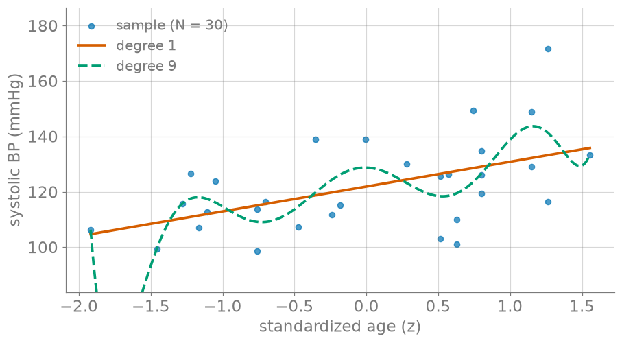

Figure 3: Same data, two bases: a degree-1 line vs. a degree-9 polynomial (over-fit).

## When is $\hat{\mathbf{w}}$ unique?

$\hat{\mathbf{w}}$ is unique **iff** $\mathbf{X}^{\!\top}\mathbf{X}$ is invertible **iff** $\mathbf{X}$ has **full column rank**:

- no feature is a linear combination of the others (**no collinearity**), and
- at least as many patients as features ($N \ge D$).

Otherwise infinitely many $\hat{\mathbf{w}}$ tie — the bowl has a flat direction.

## Recap & checkpoint preview

Least squares, closed form:

1. **Normal equations** — $\mathbf{X}^{\!\top}\mathbf{X}\hat{\mathbf{w}} = \mathbf{X}^{\!\top}\mathbf{y}$ from $\nabla\mathcal{L}=0$.
2. **Projection** — $\hat{\mathbf{y}}$ is the orthogonal projection of $\mathbf{y}$ onto $\mathrm{col}(\mathbf{X})$; $\mathbf{X}^{\!\top}\mathbf{r}=\mathbf{0}$.
3. **Uniqueness** — full column rank ⇔ invertible $\mathbf{X}^{\!\top}\mathbf{X}$.

**Checkpoint quiz 1.1** (Week 2, D2L) gates milestone 1.1 on reproducing the $\nabla\mathcal{L}=0 \Rightarrow \hat{\mathbf{w}}$ derivation; the numerical check lives in Homework Unit 1.